# Stats 250: MWrite 2 Supplement

Elan Grossman

2023-11-09

## Instructions

Instead of a lab assignment this week, you will be completing your analysis for the second MWrite assignment. Each of the 10 questions will be graded out of 5 points (for a total of 50 points). These questions will be graded for *correctness*. Upon completion, follow the submission instructions at the bottom of this document. We strongly encourage you to work on this assignment with a partner, **but everyone must submit their own document to Canvas**. Additionally, please note that there is no submission for Lab 7. The only document that you will submit today is the `mwrite2_supplement.html` file - and this will be submitted to the corresponding supplemental work assignment on Canvas.

## Background

The Equity in Athletics Disclosure Act (EADA) is a federal law passed in 1994 that was designed to make prospective students and prospective student-athletes aware of a school’s commitment to providing equitable athletic opportunities for its students. Because of the EADA, all colleges that receive Title IV funding are required to make their athletics data publicly available. There are many variables that each college must report – our MWrite data sets contain some of these variables. During this supplement, you will complete two different statistical analyses, outlined below.

Be sure to load in any required packages first!

```r
library(ggplot2)
```

### Analysis 1: Independent Scenario

#### Data (eada)

The first data set, `eada`, contains a random sample of 169 schools (that compete in Division 1 athletics). For these schools, the following information has been recorded for the 2021-2022 academic year:

- `school_type`: whether the school is private or public
- `student_aid_total`: the amount of money spent on student aid for male and female athletes (in millions of dollars)
- `recruiting_total`: the amount of money spent on recruiting male and female student athletes (in thousands of dollars)
- `expenses_total`: the amount of money spent on men’s and women’s athletic programs (in millions of dollars)

Note: be sure to pay close attention to the units!

Use the following code to read in the data:

```r
eada <- read.csv("eada_sample.csv", row.names = 1)
```

#### Goal of Analysis 1

Run an analysis to compare the funding of private and public institutions. You will choose one of the the variables above (`student_aid_total`, `recruiting_total`, or `expenses_total`) and compare the average amounts for private and public school.

> **1.** First, choose a variable for your analysis. Then, identify the variable types (categorical or quantitative) and variable roles (response and explanatory).

*Options:* Copy one of the options below and paste it into Answer 1

- amount of money spent on student aid for male and female athletes
- amount of money spent on recruiting male and female student athletes
- amount of money spent on men’s and women’s athletic programs

*Answer 1:* We wish to assess if there is a difference between the average amount of money spent on recruiting male and female athletes between public and private institutions.

*Answer 2:* The average amount of money spent on recruiting is acting as the response variable and the school type is acting as the explanatory variable.

*Answer 3:* `school_type` is a categorical variable and `recruiting_total` is a quantitative variable.

> **2.** Use notation to state the null and alternative hypothesis. Then, define your parameter of interest within context.

*H0:* μ1(private) - μ2(public) = 0

In this context, the null hypothesis asserts that there is no difference in the means of the amount of money spent on men’s and women’s recruiting between private (μ1) and public (μ2) institutions.

*Ha:* μ1 ≠ μ2

The alternative hypothesis suggests that there is a significant difference in the means of the amount of money spent on men’s and women’s recruiting between private and public institutions.

*Parameter definition:* The parameter of interest in this context is the difference in the population means of the amount of money spent on recruiting male and female student athletes between private and public institutions.

> **3.** First, use the `table()` function to determine how many schools fall into each `school_type` (Private and Public). Then, use `ggplot()` to create a *faceted* histogram for your variable of interest *by school type*. Finally, use the `aggregate()` function to compute the mean for your variable of interest *by school type*. Are these values parameters or statistics?

```r
table(eada$school_type)
```

```
##
## Private  Public
##      78      91
```

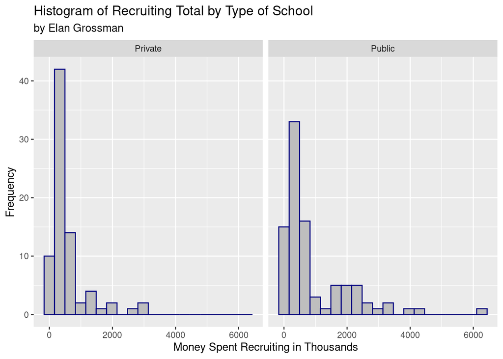

```r
library(ggplot2)
ggplot(eada, aes(x = recruiting_total)) +
  geom_histogram(bins = 20,
                 color = "navy",
                 fill = "gray")+
  facet_wrap(~school_type) +
   labs(title = "Histogram of Recruiting Total by Type of School",
       subtitle = "by Elan Grossman",
       x = "Money Spent Recruiting in Thousands",
       y = "Frequency")
```

```r
aggregate(eada$recruiting_total ~ school_type,
          data = eada,
          FUN = mean)
```

```
##   school_type eada$recruiting_total
## 1     Private              570.2240
## 2      Public              931.3546
```

*Answer:* These values are statistics because they come from samples.

> **4.** First, use `ggplot()` to create a *faceted* QQ plot for your variable of interest by school type. Based on your plots, answer the following questions: (1) Observations about the samples: what can we conclude about each sample distribution? (2) Conclusion about the population distributions: based on each sample distribution, what is reasonable to conclude about each population distribution? (3) Conclusion about the sampling distribution: based on each population distribution and the sample sizes (computed in Exercise 3), what is reasonable to conclude about the sampling distribution needed to perform the analysis?

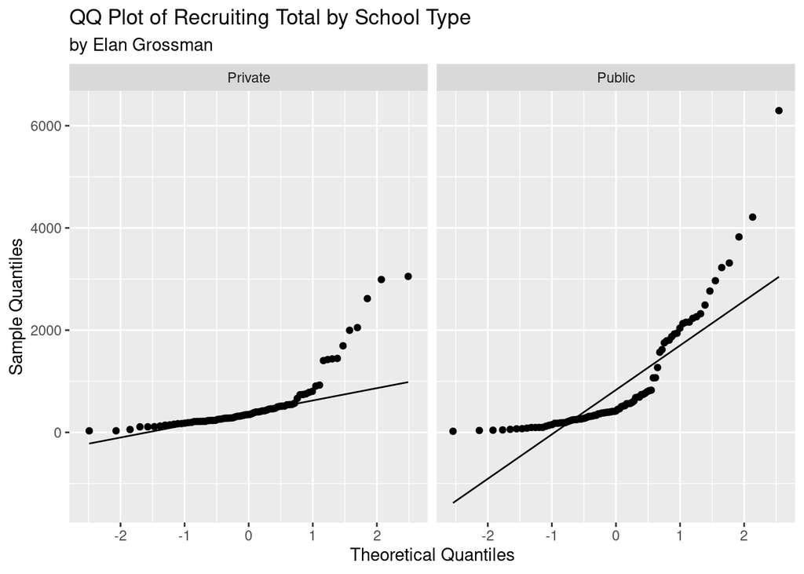

```r
ggplot(eada, aes(sample = recruiting_total)) +
  geom_qq() +
  stat_qq_line() +
  facet_wrap(~school_type) +
  labs(title = "QQ Plot of Recruiting Total by School Type",
       subtitle = "by Elan Grossman",
       x = "Theoretical Quantiles",
       y = "Sample Quantiles")
```

*Observations about the samples:* We can observe from our plots that for both public and private schools, the dots do not roughly follows the line. In addition, the histogram for each private and public school is skewed to the right. Both of these tell us that the sample distributions for both public and private schools are not normal.

*Conclusion about the population distributions:* Because the sample data for both the private and public schools don’t follow a normal distribution, we can assume that these samples were drawn from population distributions that are not normal.

*Conclusion about the sampling distribution:* Even though the population distribution does not appear to be normal, we can say that the sampling distribution is approximately normal because the sample size is greater than 25, which means according to the CLT we can move on with our analysis.

> **5.** Use the `t.test()` function to run the hypothesis test. Based on the output, evaluate the p-value and provide a conclusion in the context of the problem.

```r
t.test(eada$recruiting_total ~ eada$school_type,
       mu = 0,
       alternative = "two.sided")
```

```
##
##  Welch Two Sample t-test
##
## data:  eada$recruiting_total by eada$school_type
## t = -2.6433, df = 146.18, p-value = 0.009105
## alternative hypothesis: true difference in means between group Private and group Public is not equal to 0
## 95 percent confidence interval:
##  -631.13478  -91.12641
## sample estimates:
## mean in group Private  mean in group Public
##              570.2240              931.3546
```

*Evaluation:* We have very strong evidence against the null hypothesis and for the alternative.

*Conclusion:* We have very strong evidence that there is a difference between the average amount of money spent on recruiting men and women between private and public schools.

### Analysis 2: Dependent (Paired) Scenario

#### Data (public)

The second data set, `public`, includes only the schools listed as “Public” from the previous `eada` data set. Additionally, we have broken down the original variables to include the funding split up by men and women (as well as variables for the differences between them):

- `student_aid_men`: the amount of student aid awarded to male student athletes (in millions of dollars)
- `student_aid_women`: the amount of student aid awarded to female student athletes (in millions of dollars)
- `student_aid_diff`: the *difference* between the amount of money spent on student aid for male and female athletes (in millions of dollars)
- `recruiting_men`: the amount of money spent on recruiting male student athletes (in thousands of dollars)
- `recruiting_women`: the amount of money spent on recruiting female student athletes (in thousands of dollars)
- `recruiting_diff`: the *difference* between the amount of money spent on recruiting male and female student athletes (in thousands of dollars)
- `expenses_men`: the amount of money spent on men’s athletic programs (in millions of dollars)
- `expenses_women`: the amount of money spent on women’s athletic programs (in millions of dollars)
- `expenses_diff`: the *difference* between the amount of money spent on men’s and women’s athletic programs (in millions of dollars)

Note: the three difference variables are calculated as *men minus women* Note: be sure to pay close attention to the units!

Use the following code to read in the data:

```r
public <- read.csv("eada_sample_public.csv", row.names = 1)
```

#### Goal of Analysis 2

Run an analysis to compare the funding of males and females. You will choose one of the the difference variables above (`student_aid_diff`, `recruiting_diff`, or `expenses_diff`) and compare the average difference in funding for males and females.

> **6.** First, choose a variable for your analysis. Then, explain why this analysis is a paired (or dependent) scenario. What is the linking factor?

*Options:* Copy one of the options below and paste it into Answer 1

- difference in the amount of money spent on student aid for male and female athletes
- difference in the amount of money spent on recruiting male and female student athletes
- difference in the amount of money spent on men’s and women’s athletic programs

*Answer 1:* We wish to assess if, on average, there is a difference in the amount of money spent on recruiting men and women for all public schools.

*Answer 2:* This analysis is a paired (or dependent) scenario because it involves comparing two related measurements on the same set of schools. In this case, the linking factor is the same set of public schools, and you are interested in the difference in funding between men’s and women’s recruiting programs for each of these schools. Each pair consists of two related measurements: the funding for men’s programs and the funding for women’s programs within the same school. This type of analysis is often used to determine whether there is a significant difference within pairs, which is why it’s considered a paired scenario.

> **7.** Use notation to state the null and alternative hypothesis. Then, define your parameter of interest within context.

*H0:* μ_diff = 0

In this context, the null hypothesis asserts that there is no difference in the average funding between men’s and women’s recruiting for all public schools. The population mean difference (μ_diff) is equal to 0, which means, on average, there is no difference in funding.

*Ha:* μ_diff ≠ 0

The alternative hypothesis suggests that there is a significant difference in the average funding between men’s and women’s recruiting for all public schools. The population mean difference (μ_diff) is not equal to 0, indicating that, on average, there is a difference in funding.

*Parameter definition:* The parameter Mu(d) is defined as the difference in population means for the average amount of money spent between recruiting males and females.

> **8.** First, use `ggplot()` to create a histogram for your differences variable Then, use the `mean()` function to compute the mean of your differences variable. Is this value a parameter or statistic?

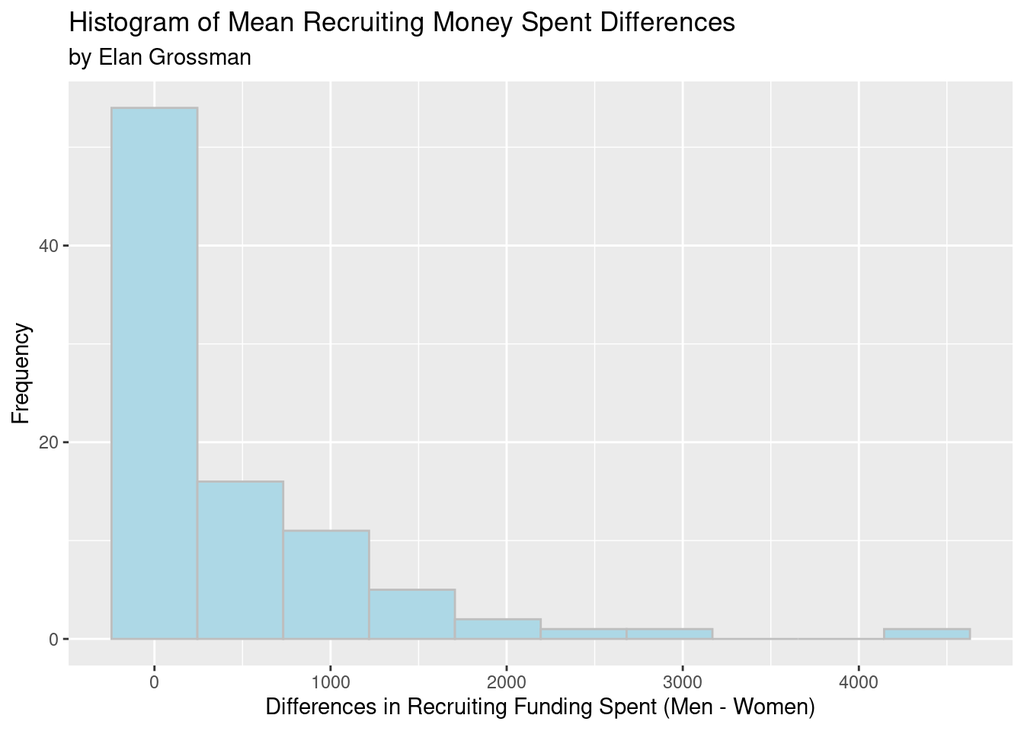

```r
ggplot(data = public, aes(x = recruiting_diff)) +
geom_histogram(bins = 10, color = "grey", fill = "lightblue") +
labs(title = "Histogram of Mean Recruiting Money Spent Differences", subtitle = "by Elan Grossman",
x = "Differences in Recruiting Funding Spent (Men - Women)",
y = "Frequency")
```

```r
mean(public$recruiting_diff)
```

```
## [1] 465.6545
```

*Answer:* They are statistics because they come from samples. In order for it to be a parameter it needs to come from the population.

> **9.** First, use `ggplot()` to create a QQ plot for your variable of interest. Based on your plot, answer the following questions: (1) Observations about the sample: what can we conclude about the sample distribution? (2) Conclusion about the population distribution: based on the sample distribution, what is reasonable to conclude about the population distribution? (3) Conclusion about the sampling distribution: based on the population distribution and the sample size, what is reasonable to conclude about the sampling distribution needed to perform the analysis?

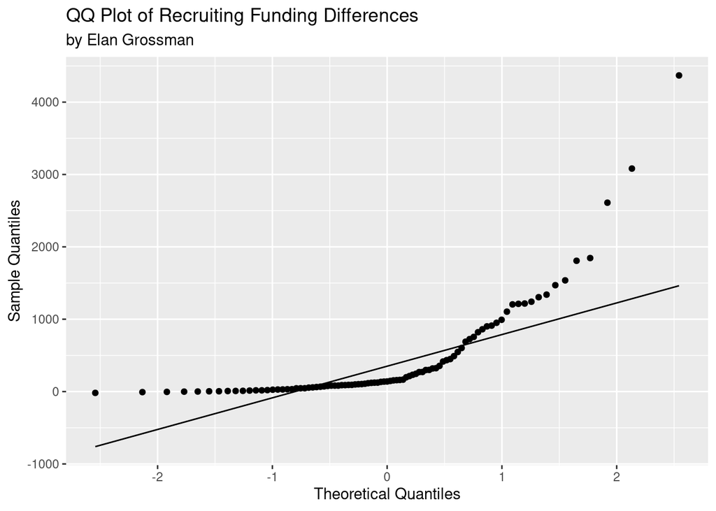

```r
ggplot(data = public, aes(sample = recruiting_diff)) + stat_qq() +
stat_qq_line() +
labs(title = "QQ Plot of Recruiting Funding Differences", subtitle = "by Elan Grossman",
x = "Theoretical Quantiles",
y = "Sample Quantiles")
```

*Observations about the sample:* The data points representing the differences in means for both men and women deviate noticeably from the identity line in the QQ plot, suggesting a non-normal distribution.

*Conclusion about the population distribution:* Since the sample data for the difference in means does not seem to follow a normal distribution, we can not assume that the sample was drawn from a normally distributed population.

*Conclusion about the sampling distribution:* According to the CLT, since the sample size of 91 is greater than 25, we can nullify the sample values matching the identity line and say that the sampling distributions are approximately normal.

> **10.** Use the `t.test()` function to run the hypothesis test. Based on the output, report both the p-value and the 95% confidence interval. Note: by running a “two.sided” test, the output will include the 95% confidence interval. Finally, would the 90% confidence interval be narrower of wider? Select one of the options below.

```r
t.test(public$recruiting_diff,
       mu = 0,
       alternative = "two.sided")
```

```
##
##  One Sample t-test
##
## data:  public$recruiting_diff
## t = 6.1642, df = 90, p-value = 1.967e-08
## alternative hypothesis: true mean is not equal to 0
## 95 percent confidence interval:
##  315.5769 615.7321
## sample estimates:
## mean of x
##  465.6545
```

*p-value:* 1.967 x 10^-08

*Confidence Interval:* The lower bound is 315.5769 and the upper bound is 615.7321.

*Answer:* The 90% confidence interval created using the same sample data would be narrower than the 95% confidence interval reported above.

## Submission Instructions

Once you have finished, follow the instructions below to submit your work.

1. At the top of the document, update the `author` field. Do not change anything else at the top of the document.
2. Click the Knit button to create an HTML file of your work.
3. In the Files pane (bottom right window), check the box next to `mwrite2_supplement.html`.
4. In the Files pane, click on the gear icon (More) and select “Export…”
5. Do not change the file name (`mwrite2_supplement.html`). Click Download and save the file to your computer.
6. On the Stats 250 Canvas site, navigate to the MWrite #2 Supplement Work assignment.
7. Upload your saved `mwrite2_supplement.html` file.
8. Click “Submit Assignment”. Congratulations, you are done with the fist part of MWrite #2! Note: there will be no file submission for the Lab 7 assignment on Canvas.